# Traumatic Brain Injury

Furkan Danisman

2024-03-23

# Functions and Definitions of the Part of the Brains

## Hippocampus-Left side

### Plays a crucial role in linguistic skills. In other words, episodic verbal memory.

## Capsules

### The internal capsule describes a region deep in the brain that functions as a communication pathway.

## Fornix Crux

### The fornix is a white matter tract that connects the hippocampus to several subcortical brain regions and is pivotal for episodic memory functioning.

## Gray Matter

### The place where the processing of sensation, perception, voluntary movement, learning, speech and cognition takes place.

### Wide-to-Long Form Data Transformation

```r
TBI <- read_excel("C:/Users/zenci/Downloads/TBI.xlsx")
TBI2 <- as.data.frame(TBI)

a <- names(TBI2)
names(TBI2) <- gsub("_(.)$","__\\1",a)
New_TBI <- tolong(TBI2,timevar = "visit",sep = "__",idvar="SubID")
New_TBI$SEX <- ifelse(New_TBI$sex==1,"Male","Female")
New_TBI_filtered <- New_TBI[complete.cases(New_TBI$SEX),]
```

### Time vs Hippocampus Left among each sex and group

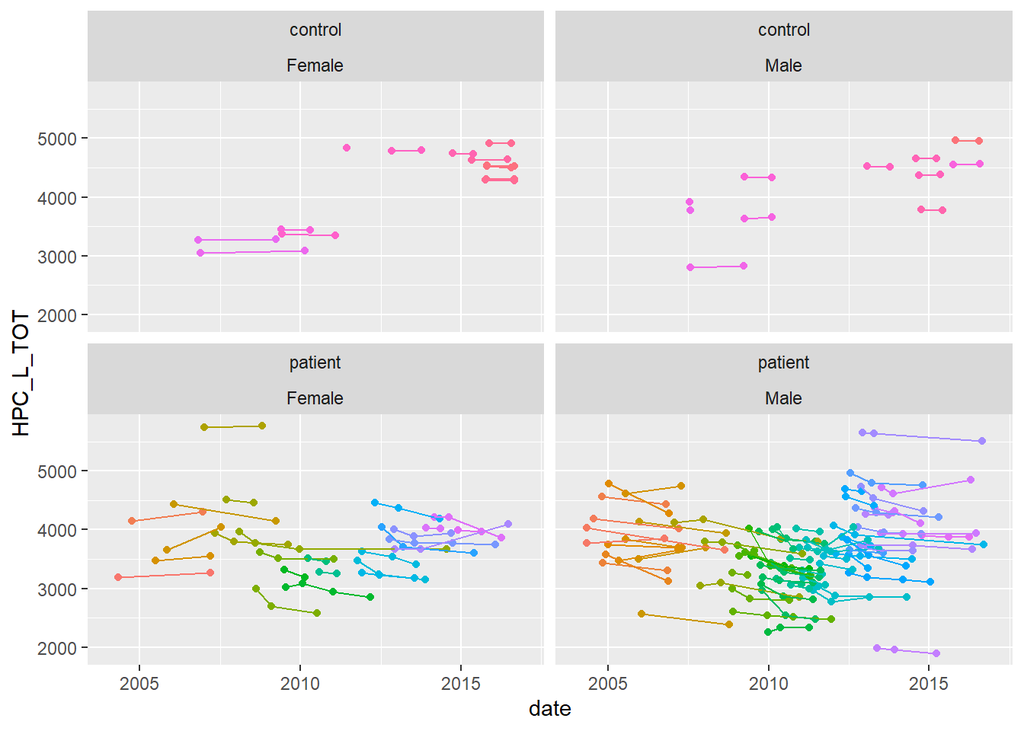

```r
HC_G_p <- ggplot(New_TBI_filtered, aes(x = date, y = HPC_L_TOT, group = SubID, col = SubID)) +
  geom_point() +
  geom_line() +
  facet_wrap(~group+SEX) +
  theme(legend.position = "none") +
  scale_y_continuous()

HC_G_p
```

### Hippocampus Left vs Fornix Cruxes

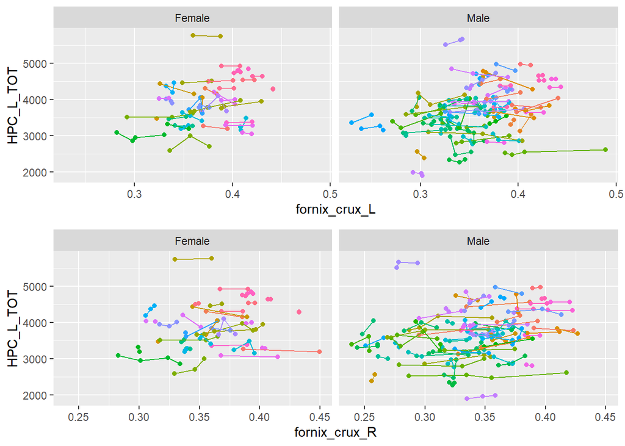

```r
HC_F_L <- ggplot(New_TBI_filtered, aes(x = fornix_crux_L, y = HPC_L_TOT, group = SubID, col = SubID)) +
  geom_point() +
  geom_line() +
  facet_wrap(~SEX) +
  theme(legend.position = "none") +
  scale_y_continuous()

HC_F_R <- ggplot(New_TBI_filtered, aes(x = fornix_crux_R, y = HPC_L_TOT, group = SubID, col = SubID)) +
  geom_point() +
  geom_line() +
  facet_wrap(~SEX) +
  theme(legend.position = "none") +
  scale_y_continuous()

grid.arrange(HC_F_L,HC_F_R)
```

```r
# Around the same relationship for both sides
```

### Hippocampus Left vs Capsule Anterior

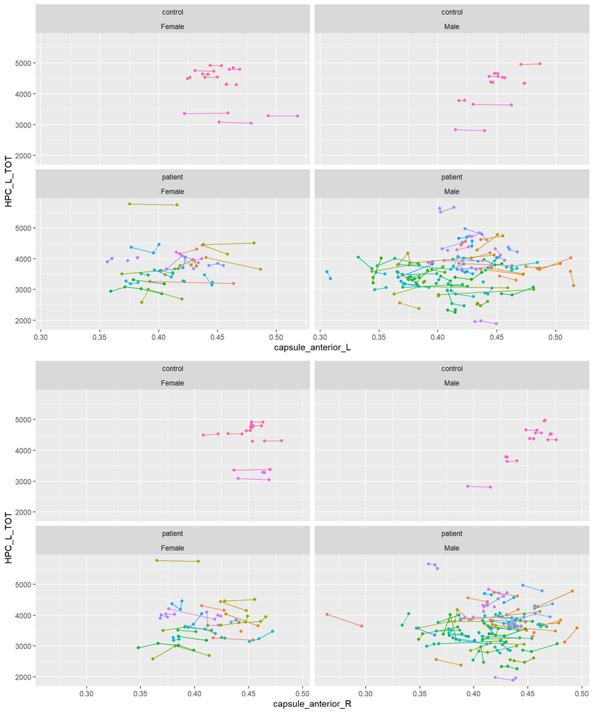

```r
HC_CA_L <- ggplot(New_TBI_filtered, aes(x = capsule_anterior_L, y = HPC_L_TOT, group = SubID, col = SubID)) +
  geom_point() +
  geom_line() +
  facet_wrap(~group+SEX) +
  theme(legend.position = "none") +
  scale_y_continuous()

HC_CA_R <- ggplot(New_TBI_filtered, aes(x = capsule_anterior_R, y = HPC_L_TOT, group = SubID, col = SubID)) +
  geom_point() +
  geom_line() +
  facet_wrap(~group+SEX) +
  theme(legend.position = "none") +
  scale_y_continuous()

grid.arrange(HC_CA_L,HC_CA_R)
```

### Hippocampus Left vs Age

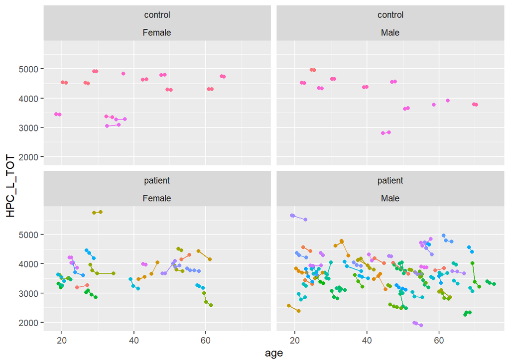

```r
HC_Age <- ggplot(New_TBI_filtered, aes(x = age, y = HPC_L_TOT, group = SubID, col = SubID)) +
  geom_point() +
  geom_line() +
  facet_wrap(~group+SEX) +
  theme(legend.position = "none") +
  scale_y_continuous()

HC_Age
```

```r
# Similar to the time plot - just the scale is a bit different
```

### Hippocampus Left vs Gray Matter

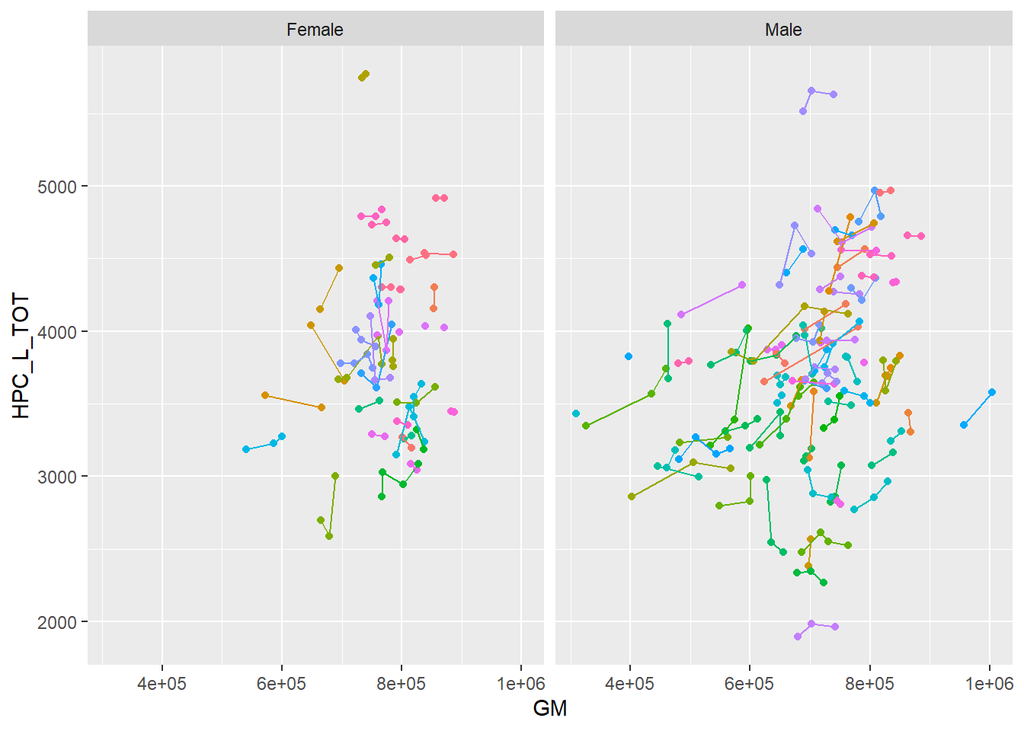

```r
HC_GM <- ggplot(New_TBI_filtered, aes(x = GM, y = HPC_L_TOT, group = SubID, col = SubID)) +
  geom_point() +
  geom_line() +
  facet_wrap(~SEX) +
  theme(legend.position = "none") +
  scale_y_continuous()

HC_GM
```

```r
# There is an observable positive relationship
```

### Data Manipulations

```r
# Data Manipulations

New_TBI_filtered$SEX <- as.factor(New_TBI_filtered$SEX)
New_TBI_filtered$group <- as.factor(New_TBI_filtered$group)
clean_TBI_WO_Ls <- subset(New_TBI_filtered,!is.na(HPC_L_TOT) & !is.na(SEX) & !is.na(age_30))
clean_TBI_W_Ls <- subset(clean_TBI_WO_Ls, !is.na(fornix_crux_L) & !is.na(capsule_anterior_R) &
                         !is.na(GM))
only_clean_HPC <- subset(New_TBI_filtered,!is.na(HPC_L_TOT))

clean_TBI_W_Ls$visit<- as.factor(clean_TBI_W_Ls$visit)
clean_TBI_W_Ls$SubID <- as.factor(clean_TBI_W_Ls$SubID)
clean_TBI_W_Ls$id <- as.factor(clean_TBI_W_Ls$id)
a <- select(clean_TBI_W_Ls,c(HPC_L_TOT,HPC_R_TOT,age_30,fornix_crux_L,capsule_anterior_R,GM,visit,SEX,group))
b <- subset(clean_TBI_W_Ls,visit==2)
c <- subset(b,age>25 & age< 50)
d <- subset(b,age<=25)
middle_age_prop <- nrow(c)/nrow(b)
young_age_prop <- nrow(d)/nrow(b)
old_age_prop <- (nrow(b) - nrow(c) - nrow(d)) / nrow(b)
Prop_age <- data.frame("Younger -25" = young_age_prop, "Middle Age 25-50"=middle_age_prop,
                       "Older 50-"=old_age_prop)
rownames(Prop_age) <- "Proportion"
colnames(Prop_age) <- c("Younger-25","Middle Age 25-50", "Older 50-")
Prop_age <- Prop_age *100
range_of_age <- range(clean_TBI_W_Ls$age_30)
```

### Age Proportion

```r
Prop_age
```

|  | Younger-25 | Middle Age 25-50 | Older 50- |
| --- | --- | --- | --- |
| Proportion | 20.86957 | 46.95652 | 32.17391 |

### QQ-plot For each X Variables

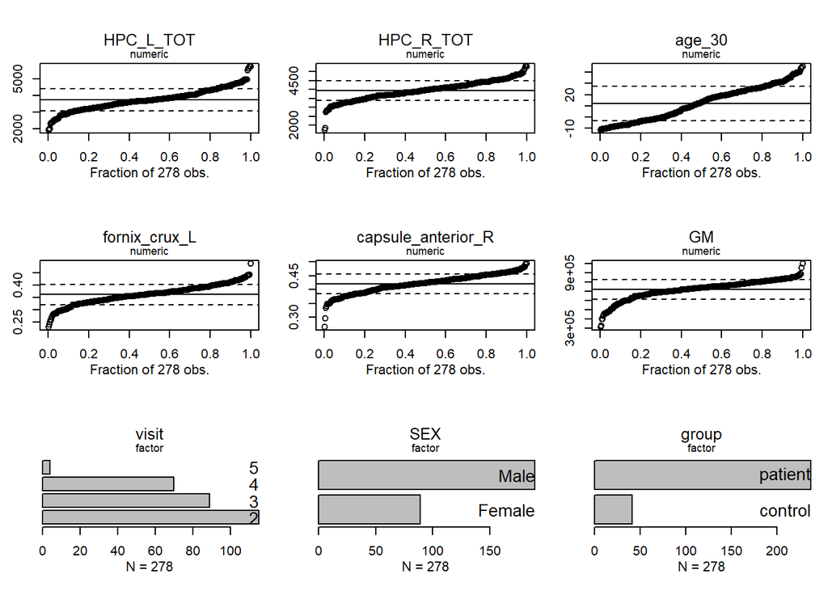

```r
xqplot(a)
```

### Models

```r
# Mixed Models

# Model with the random part

fit.wLs <-lme( HPC_L_TOT ~ SEX + age_30 +group*age_30 + capsule_anterior_R +
                 GM  + fornix_crux_L, clean_TBI_W_Ls,
               random = ~ 1 + age_30 | SubID, correlation = corCAR1(form = ~ age_30 | SubID) )

# Model without the random part

fit.wLs2 <- gls( HPC_L_TOT ~ SEX + age_30 + group*age_30 + capsule_anterior_R +GM  + fornix_crux_L, clean_TBI_W_Ls )

# Testing G-matrix

anova(fit.wLs,fit.wLs2)
```

|  | call | Model | df | AIC | BIC | logLik | Test | L.Ratio | p-value |
| --- | --- | --- | --- | --- | --- | --- | --- | --- | --- |
| fit.wLs | lme.formula(fixed = HPC_L_TOT ~ SEX + age_30 + group * age_30 + capsule_anterior_R + GM + fornix_crux_L, data = clean_TBI_W_Ls, random = ~1 + age_30 \| SubID, correlation = corCAR1(form = ~age_30 \| S… | 1 | 13 | 3867.848 | 3914.627 | -1920.924 |  | NA | NA |
| fit.wLs2 | gls(model = HPC_L_TOT ~ SEX + age_30 + group * age_30 + capsule_anterior_R + GM + fornix_crux_L, data = clean_TBI_W_Ls) | 2 | 9 | 4314.952 | 4347.338 | -2148.476 | 1 vs 2 | 455.1045 | 3.422169e-97 |

```r
# G-matrix is significantly greater than 0

# Model Updates to compare models - Section 1

fit2 <- update( fit.wLs, . ~ . + SEX*age_30)
fit4 <- update( fit2, . ~ . + cvar(GM,SubID)) # To factor in variability between subjects
fit2l.1 <- fit4
```

### Diagnostic for heteroskedasticity —-

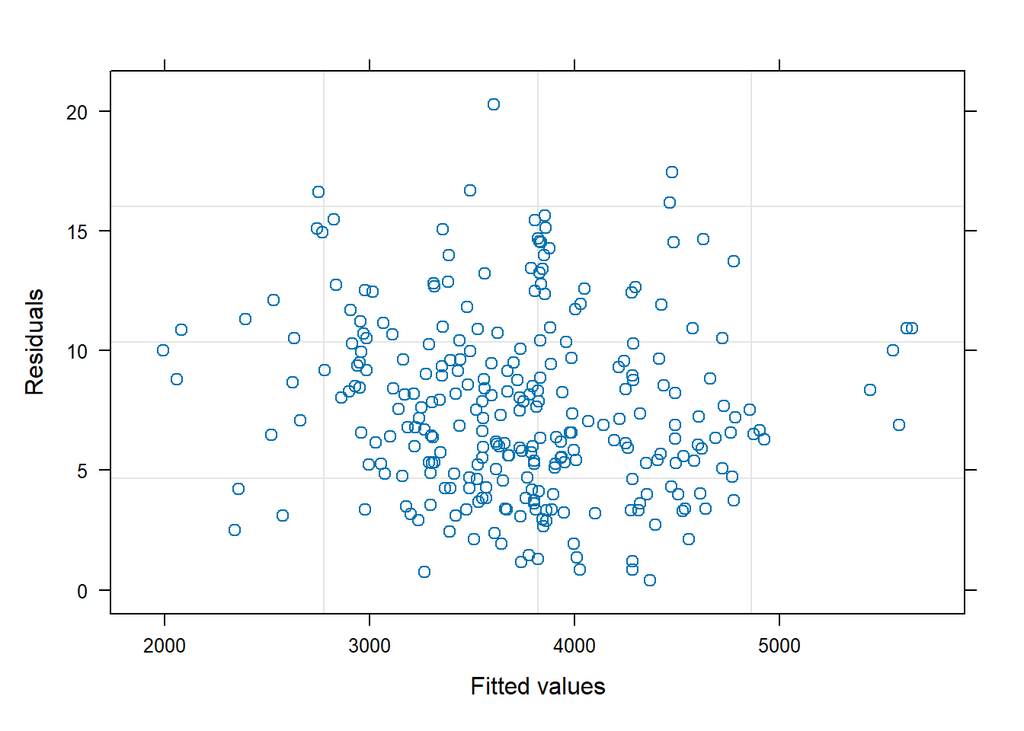

```r
plot( fit2l.1, sqrt( abs( resid(.))) ~ fitted(.), id = .02) # exploratory version
```

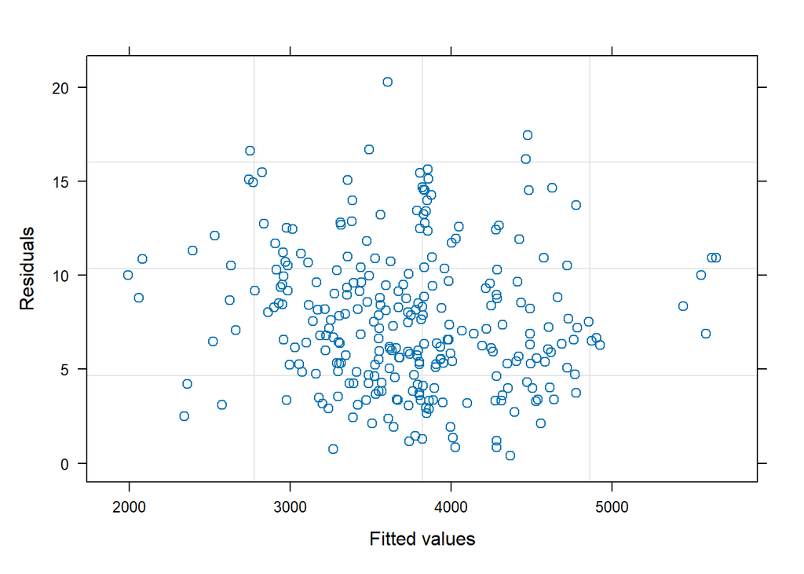

```r
# fancy version
plot( fit2l.1, sqrt( abs( resid(.))) ~ fitted(.), id = .02)
```

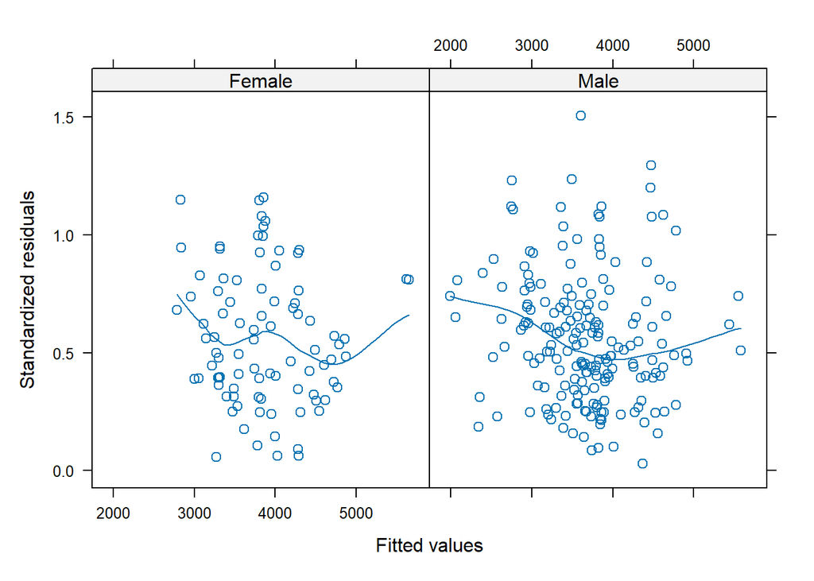

```r
plot( fit2l.1, sqrt( abs( resid(., type = 'p'))) ~ fitted(.) | SEX, id = .03,
      panel = function(x, y, ...) {
        panel.xyplot( x, y, ...)
        panel.loess( x, y,...)
      })
```

```r
# id didn't work so we do it manually

#trellis.focus()
#panel.identify(labels = clean_TBI_W_Ls$SubID)
#trellis.unfocus()
```

### Identified Points: SubID = { 368 - 380 - 325 - 462 - 346 - 453 - 358 }

```r
sus <- c(368,380,325,462,346,453,358)
subset_data <- subset(clean_TBI_W_Ls,SubID %in% sus)
```

### Plotting the highlighted “suspicious patients”.

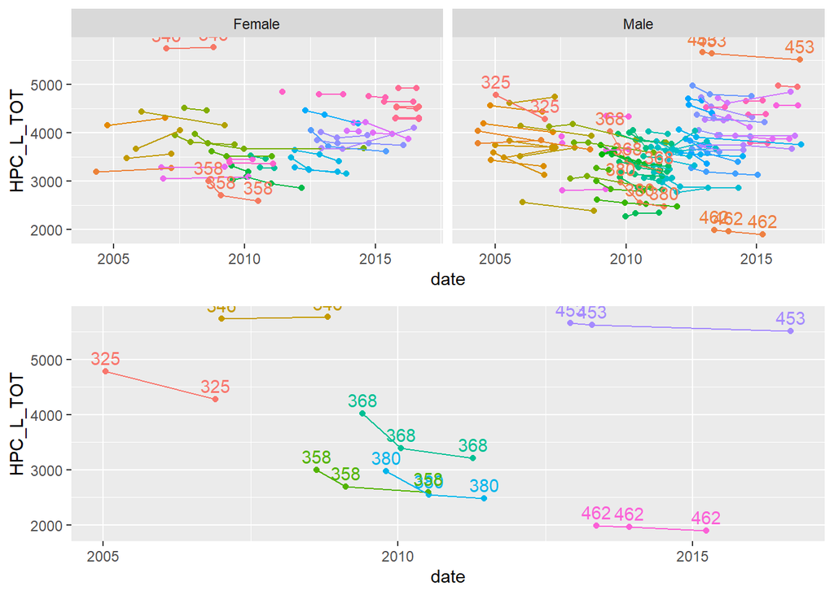

```r
HC_Sample2.1 <- ggplot(New_TBI_filtered, aes(x = date, y = HPC_L_TOT, group = SubID, col = SubID)) +
  geom_point() +
  geom_line() +
  facet_wrap(~SEX) +
  theme(legend.position = "none") +
  geom_text(data = subset(subset_data, SubID %in% sus),
            aes(label = SubID), vjust = -0.5) +
  scale_y_continuous()

HC_sample2 <- ggplot(data = subset_data,aes(x=date,y=HPC_L_TOT,col=SubID,group=SubID))+
  geom_point()+
  geom_line()+
  theme(legend.position="none")+
  geom_text(data = subset(subset_data, SubID %in% sus),
            aes(label = SubID), vjust = -0.5)+
  scale_y_continuous()

grid.arrange(HC_Sample2.1,HC_sample2)
```

```r
possible_rmv <- c(346)
```

### QQnorms

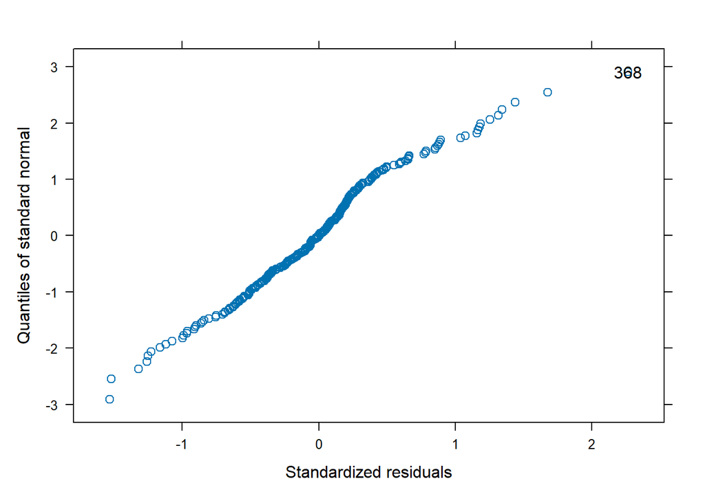

```r
qqnorm( fit2l.1, id = .05 )
```

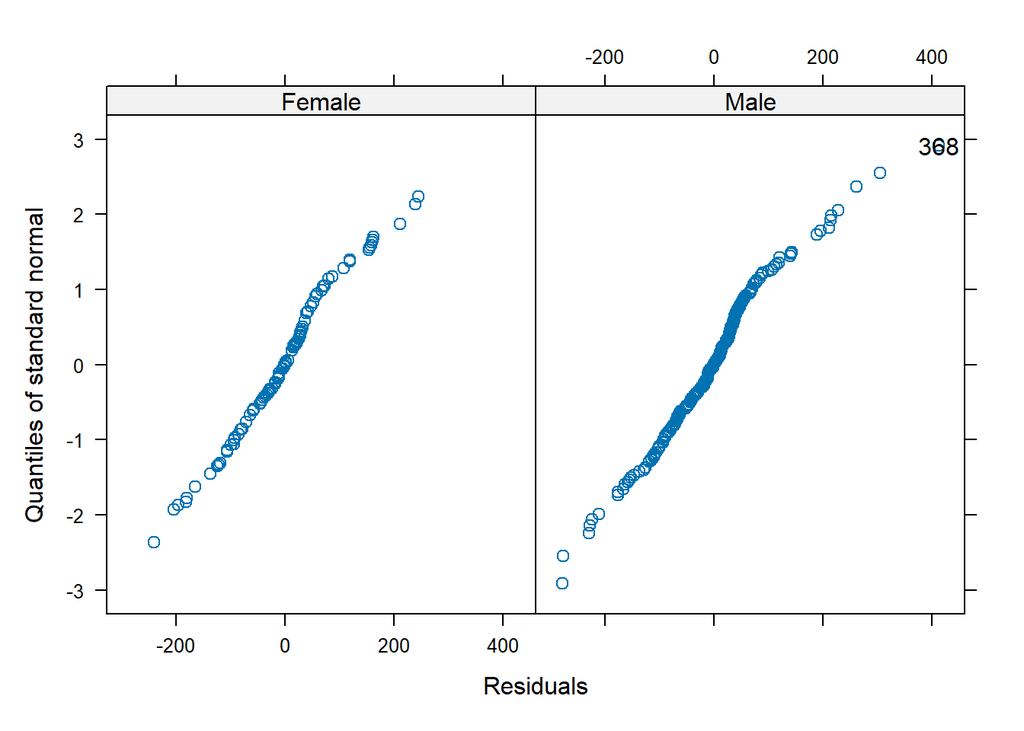

```r
qqnorm( fit2l.1, ~ resid(.) | SEX, id = .05 )
```

### Should we drop some observations?

```r
possible_rmv <- c(346)

fit2l.d <- update( fit2l.1, data = subset(clean_TBI_W_Ls, !(id %in% possible_rmv)) )

# or

fit2l.d <- update( fit2l.1, subset = !(id %in% possible_rmv) )
```

### Heteroscedasticity revisited

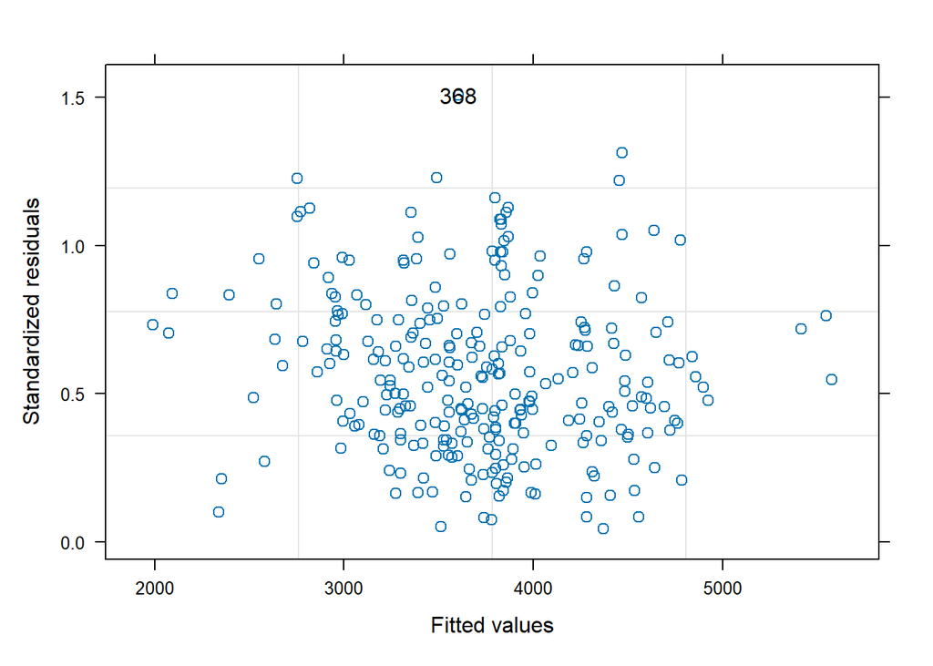

```r
plot( fit2l.d, sqrt( abs( resid(., type = 'p'))) ~ fitted(.), id = .03)
```

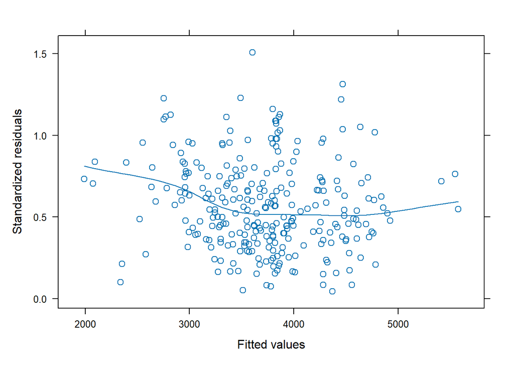

```r
plot( fit2l.d, sqrt( abs( resid(., type = 'p'))) ~ fitted(.), id = .03,
      panel = function(x, y, ...) {
        panel.xyplot( x, y, ...)
        panel.loess( x, y,...)
      })
```

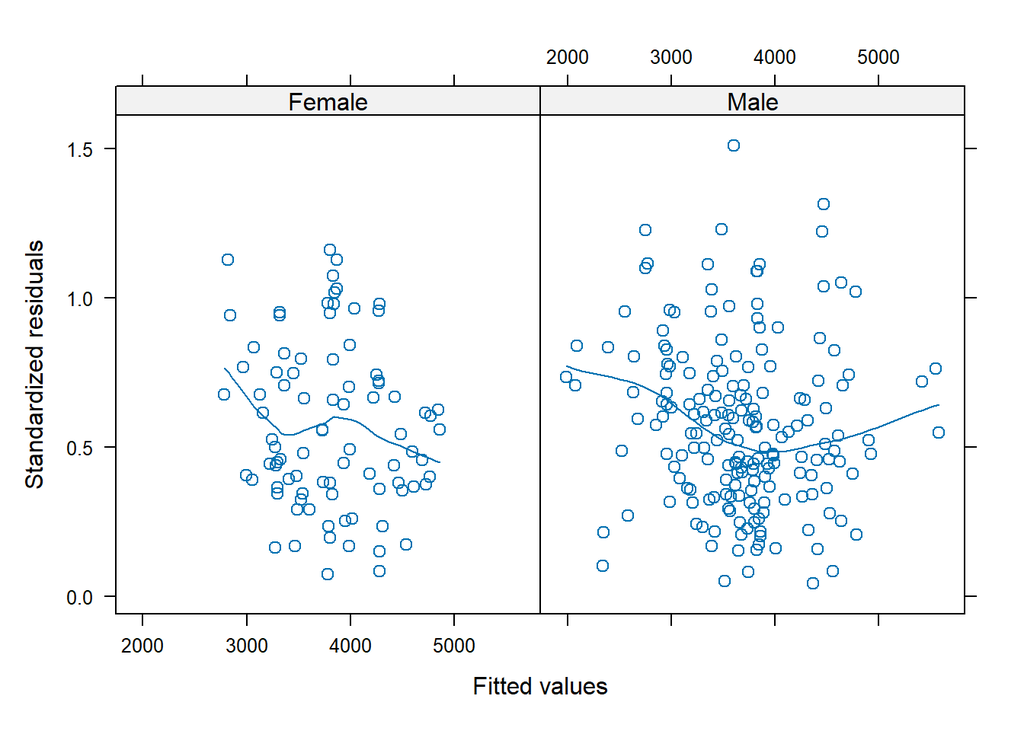

```r
plot( fit2l.d, sqrt( abs( resid(., type = 'p'))) ~ fitted(.) | SEX, id = .03,
      panel = function(x, y, ...) {
        panel.xyplot( x, y, ...)
        panel.loess( x, y,...)
      })
```

### QQnorms

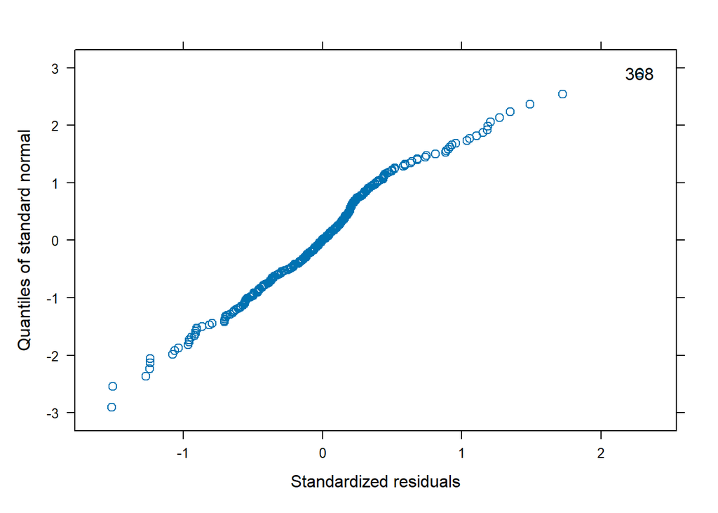

```r
qqnorm( fit2l.d, id = .05 )
```

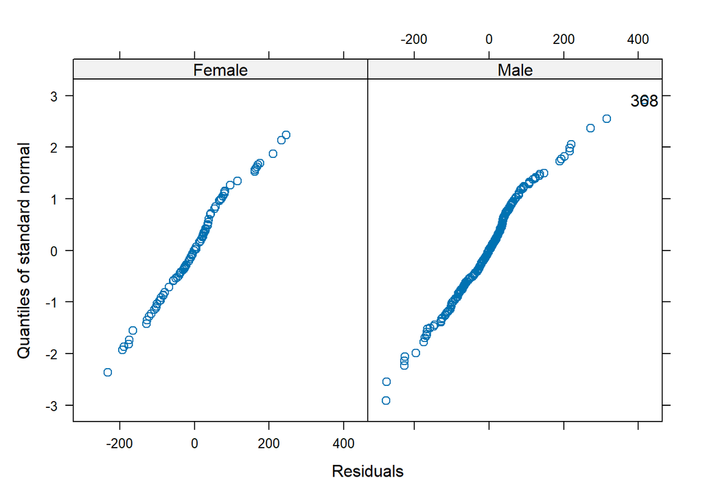

```r
qqnorm( fit2l.d, ~ resid(.) | SEX, id = .05 )
```

### Variogram: diagnostics for autocorrelation

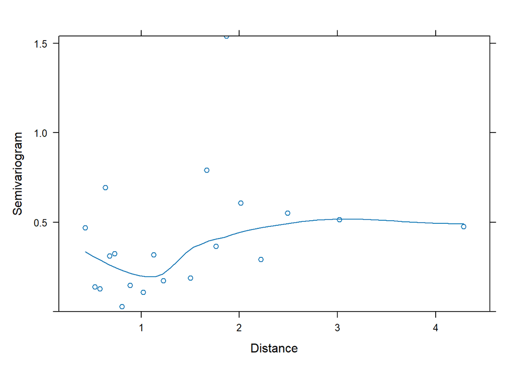

```r
vv <- Variogram( fit2l.d , form = ~ age_30 | SubID, maxdist = .7)
plot(vv)
```

```r
# Differences between pairs of close residuals have smaller variance than between far apart ones.
```

### Model Comparison

```r
w.fit <- wald(fit.wLs)[[1]]
a <- w.fit$anova
w.fit2 <- wald(fit2)[[1]]
b <- w.fit2$anova
w.fit4 <- wald(fit4)[[1]]
c <- w.fit4$anova
w.fitd <- wald(fit2l.d)[[1]]
d <- w.fitd$anova
a <- as.matrix(a)
b <- as.matrix(b)
c <- as.matrix(c)
d <- as.matrix(d)
e <- cbind(a,b,c,d)
colnames(e) <- c("Fit","Fit-Interaction","Fit-Contextual","Fit-W/outlier")
e
```

```
##         Fit          Fit-Interaction Fit-Contextual Fit-W/outlier
## numDF   8            9               10             10
## denDF   113          113             112            111
## F-value 528.9135     475.3642        424.964        468.5714
## p-value 8.828284e-86 1.902375e-85    3.797777e-84   7.182492e-86
```

```r
# The p-value for all of them is relatively low. We can continue with the final model.
```

## Final Model

### Y variable: Left-Hippocampus-Total (Volume)

### X variables:

### Fixed Part: Sex + Age (Centered at 30) + Sex*Age (Centered at 30) + Group*Age (Centered at 30) + Group + Capsule Anterior-R + Gray Matter + Fornix Crux - L + cvar(Gray Matter)

### Random Part: Intercept + Age_30 conditioned on subject

### Correlation: ~ Age_30 | Subject

## Questions

### Q1 - Does the hippocampus volume undergo significant changes after an injury, and do these changes vary over time post-injury?

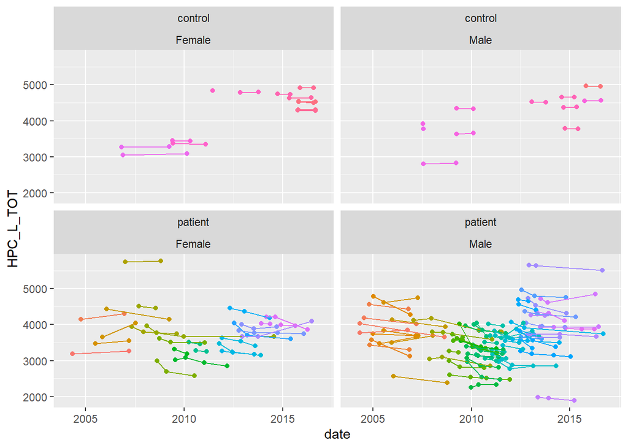

```r
# Answer1: Since we do not have pre-injury data, we can not conclude if the changes are significant or natural.

# Answer2: However, we can observe the pattern after the injury, factoring in other variables. For example, we can observe how different the patients are compared to the control group. There appears to be a change in the slope for the two groups.

# Plot vs time wrapped by group and sex
HC_G_p # Let's revisit the graph
```

```r
# Wald-Test

wald(fit2l.d,"group")
```

```
##       numDF denDF  F-value p-value
## group     2   111 5.170971 0.00713
##                     Estimate   Std.Error DF  t-value   p-value Lower 0.95
## grouppatient        -510.69538 182.95988 111 -2.791297 0.00618 -873.24260
## age_30:grouppatient    1.88908  10.73275 155  0.176011 0.86052  -19.31227
##                     Upper 0.95
## grouppatient        -148.14816
## age_30:grouppatient   23.09043
```

```r
# Also, there seems to be a significant difference of 510 Hippocampus (TOT) in the intercept between patients and the control group. However, for the slope, there is a small difference of 1.89 for the patients. Although difference in slope itself is not significant, at d=2 level group variable is highly significant with the p-value of 0.007
```